# UD651 - Problem Set 4

Ivan Heneghan

16 January 2016

This is the project report for UD651 - Problem Set 4.

Load relevant libraries:

```r
library(data.table)
library(plyr)
library(dplyr, warn.conflicts = FALSE)
library(ggplot2)
library(gridExtra)
library(lubridate)
library(reshape2)
library(tidyr)
library(xlsx)
```

1. Scatterplot - price vs x

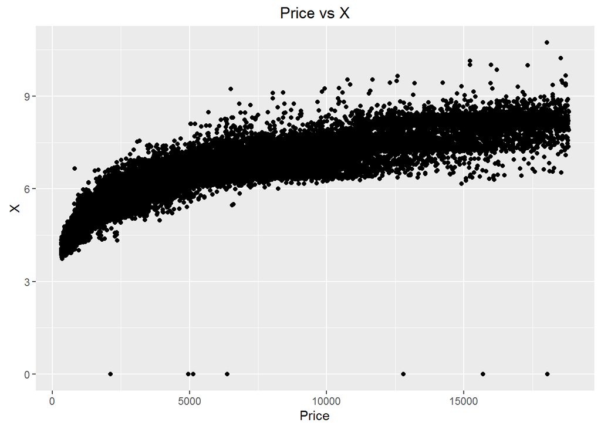

```r
ggplot(data = diamonds, aes(x = price, y = x)) +
  geom_point() +
  xlab("Price") +
  ylab("X") +
  ggtitle("Price vs X")
```

2. Correlations - price vs. x, y, z

```r
with(diamonds, cor.test(price, x, method = "pearson"))
```

```
##
##  Pearson's product-moment correlation
##
## data:  price and x
## t = 440.16, df = 53938, p-value < 2.2e-16
## alternative hypothesis: true correlation is not equal to 0
## 95 percent confidence interval:
##  0.8825835 0.8862594
## sample estimates:
##       cor
## 0.8844352
```

```r
with(diamonds, cor.test(price, y, method = "pearson"))
```

```
##
##  Pearson's product-moment correlation
##
## data:  price and y
## t = 401.14, df = 53938, p-value < 2.2e-16
## alternative hypothesis: true correlation is not equal to 0
## 95 percent confidence interval:
##  0.8632867 0.8675241
## sample estimates:
##       cor
## 0.8654209
```

```r
with(diamonds, cor.test(price, z, method = "pearson"))
```

```
##
##  Pearson's product-moment correlation
##
## data:  price and z
## t = 393.6, df = 53938, p-value < 2.2e-16
## alternative hypothesis: true correlation is not equal to 0
## 95 percent confidence interval:
##  0.8590541 0.8634131
## sample estimates:
##       cor
## 0.8612494
```

3. Scatterplot - price vs depth

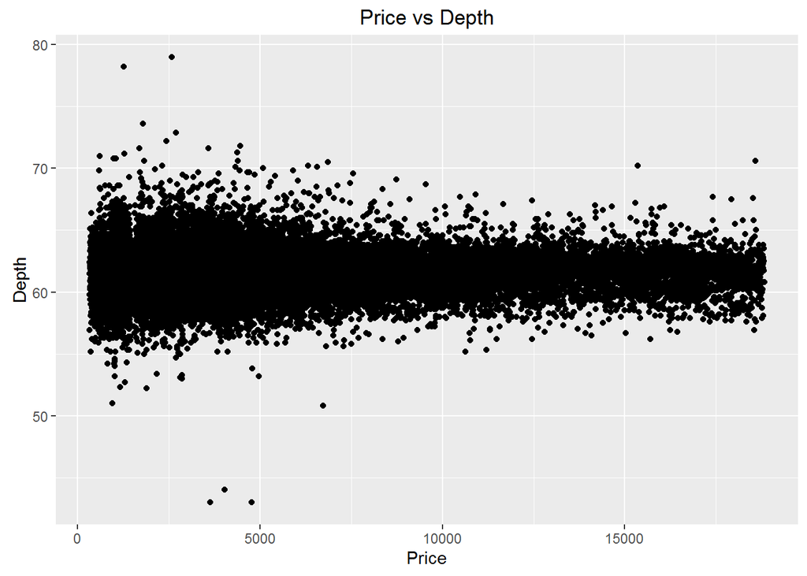

```r
ggplot(data = diamonds, aes(x = price, y = depth)) +
  geom_point() +
  xlab("Price") +
  ylab("Depth") +
  ggtitle("Price vs Depth")
```

4. Scatterplot - price vs depth adjustments

```r
range(diamonds$depth)
```

```
## [1] 43 79
```

4b. Plot

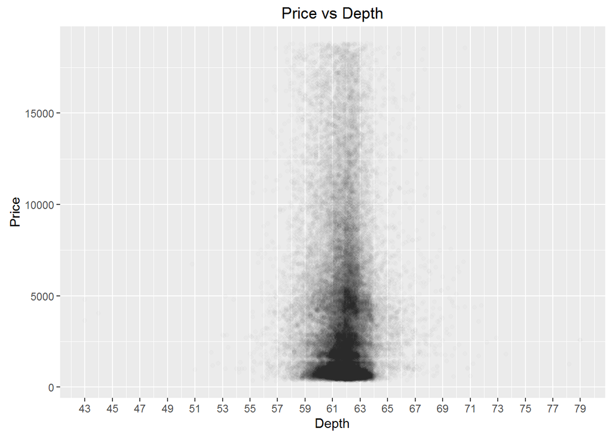

```r
ggplot(data = diamonds, aes(x = depth, y = price)) +
  geom_point(alpha = 1/100) +
  scale_x_continuous(breaks = seq(43, 79, 2)) +
  xlab("Depth") +
  ylab("Price") +
  ggtitle("Price vs Depth")
```

4c. Correlation of price & depth

```r
with(diamonds, cor.test(price, depth, method = "pearson"))
```

```
##
##  Pearson's product-moment correlation
##
## data:  price and depth
## t = -2.473, df = 53938, p-value = 0.0134
## alternative hypothesis: true correlation is not equal to 0
## 95 percent confidence interval:
##  -0.019084756 -0.002208537
## sample estimates:
##        cor
## -0.0106474
```

5. Scatterplot - price vs carat

```r
range(diamonds$carat)
```

```
## [1] 0.20 5.01
```

5b. Plot

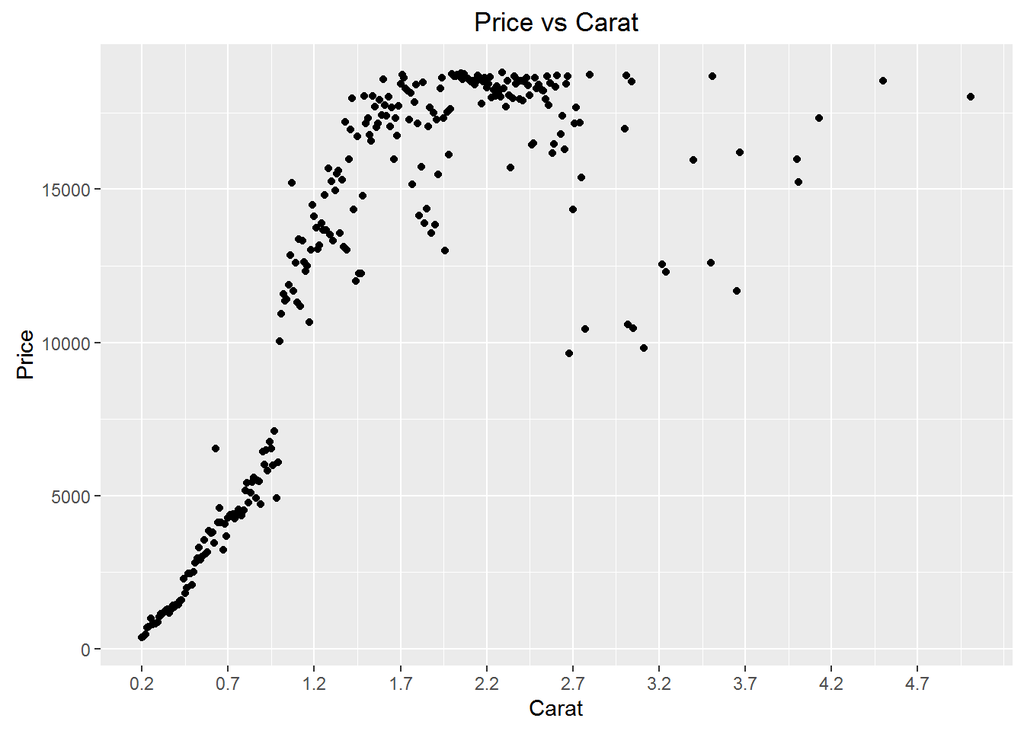

```r
ggplot(data = diamonds, aes(x = carat, y = price)) +
  geom_point(stat = "summary", fun.y = quantile, fun.args = list(probs = .99)) +
  scale_x_continuous(breaks = seq(0.2, 5.01, 0.5)) +
  xlab("Carat") +
  ylab("Price") +
  ggtitle("Price vs Carat")
```

6. Scatterplot - price vs volume

6a. Create volume variable

```r
diamonds$volume <- diamonds$x * diamonds$y * diamonds$z
range(diamonds$volume)
```

```
## [1]    0.000 3840.598
```

6b. Scatterplot

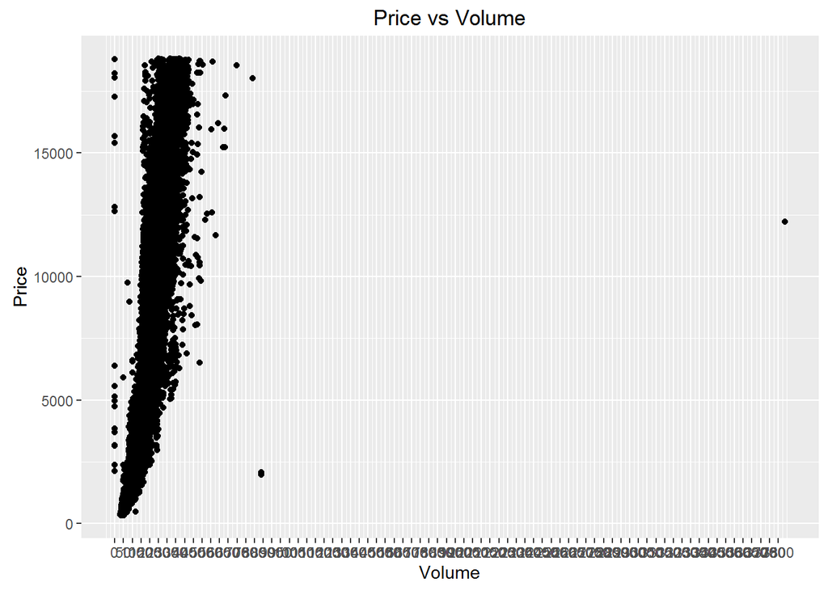

```r
ggplot(data = diamonds, aes(x = volume, y = price)) +
  geom_point() +
  scale_x_continuous(breaks = seq(0, 3841, 50)) +
  xlab("Volume") +
  ylab("Price") +
  ggtitle("Price vs Volume")
```

7. Scatterplot - removing outliers through subset

7a. Create subsetted data set

```r
diamondsReduced <- subset(diamonds, volume > 0 & volume <= 800)
```

7b. Correlation of this

```r
with(diamondsReduced, cor.test(price, volume, method = "pearson"))
```

```
##
##  Pearson's product-moment correlation
##
## data:  price and volume
## t = 559.19, df = 53915, p-value < 2.2e-16
## alternative hypothesis: true correlation is not equal to 0
## 95 percent confidence interval:
##  0.9222944 0.9247772
## sample estimates:
##       cor
## 0.9235455
```

7c. Adjustments

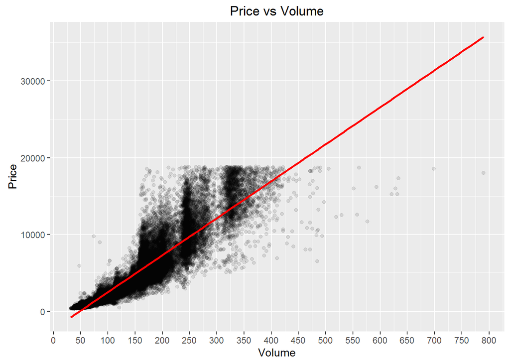

```r
ggplot(data = diamondsReduced, aes(x = volume, y = price)) +
  geom_point(alpha = 1/10) +
  geom_smooth(method = "lm", color = "red") +
  scale_x_continuous(breaks = seq(0, 3841, 50)) +
  xlab("Volume") +
  ylab("Price") +
  ggtitle("Price vs Volume")
```

8. Mean price by clarity

8a. Creation of the new data frame

```r
diamondsByClarity <- diamonds %>%
  group_by(clarity) %>%
  summarise(mean_price = mean(price),
            median_price = median(price),
            min_price = min(price),
            max_price = max(price),
            n = n()) %>%
  arrange(clarity)
```

8b. Bar charts of mean price

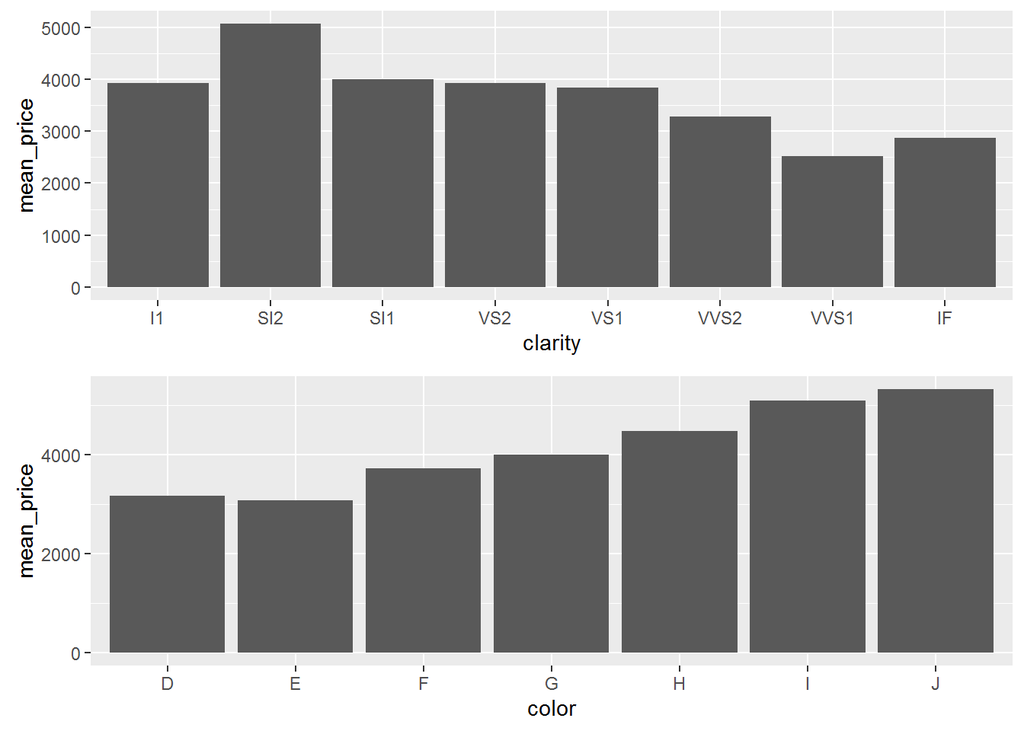

```r
diamonds_by_clarity <- group_by(diamonds, clarity)
diamonds_mp_by_clarity <- summarise(diamonds_by_clarity, mean_price = mean(price))

diamonds_by_color <- group_by(diamonds, color)
diamonds_mp_by_color <- summarise(diamonds_by_color, mean_price = mean(price))

g1 <- ggplot(data = diamonds_mp_by_clarity, aes(x = clarity, y = mean_price)) +
  geom_bar(stat="identity")
g2 <- ggplot(data = diamonds_mp_by_color, aes(x = color, y = mean_price)) +
  geom_bar(stat="identity")
grid.arrange(g1, g2, ncol = 1)
```

8c. Looking at mean price/cut relationship

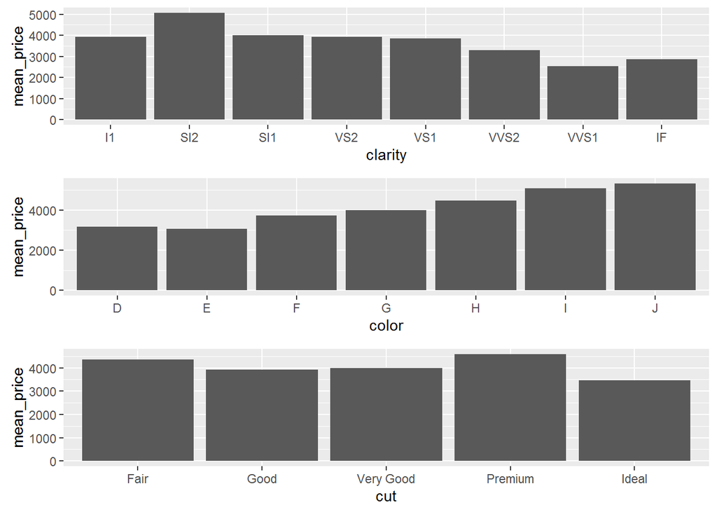

```r
diamonds_by_cut <- group_by(diamonds, cut)
diamonds_mp_by_cut <- summarise(diamonds_by_cut, mean_price = mean(price))
g3 <- ggplot(data = diamonds_mp_by_cut, aes(x = cut, y = mean_price)) +
  geom_bar(stat="identity")
grid.arrange(g1, g2, g3, ncol = 1)
```

9. Gapminder revisited - look at link between mobile phone ownership & income per person/GDP per capita.

9a. Go to right directory

9b. Import data

```r
cell <- read.csv("cell phone per 100.csv", 1, stringsAsFactors = FALSE)
gdp <- read.csv("GDPpercapitaconstant2000US.csv", 1, stringsAsFactors = FALSE)
```

9c. Check data

```r
str(cell)
```

```
## 'data.frame':    275 obs. of  48 variables:
##  $ Mobile.cellular.subscriptions..per.100.people.: chr  "Abkhazia" "Afghanistan" "Akrotiri and Dhekelia" "Albania" ...
##  $ X1965                                         : int  NA 0 NA 0 0 0 0 0 NA 0 ...
##  $ X1966                                         : logi  NA NA NA NA NA NA ...
##  $ X1967                                         : logi  NA NA NA NA NA NA ...
##  $ X1968                                         : logi  NA NA NA NA NA NA ...
##  $ X1969                                         : logi  NA NA NA NA NA NA ...
##  $ X1970                                         : int  NA 0 NA 0 0 0 0 0 NA 0 ...
##  $ X1971                                         : logi  NA NA NA NA NA NA ...
##  $ X1972                                         : logi  NA NA NA NA NA NA ...
##  $ X1973                                         : logi  NA NA NA NA NA NA ...
##  $ X1974                                         : logi  NA NA NA NA NA NA ...
##  $ X1975                                         : int  NA 0 NA 0 0 0 0 0 NA 0 ...
##  $ X1976                                         : int  NA 0 NA 0 0 0 0 0 NA 0 ...
##  $ X1977                                         : int  NA 0 NA 0 0 0 0 0 NA 0 ...
```

[output cut: 34 more lines]

```r
head(cell)
```

```
##   Mobile.cellular.subscriptions..per.100.people. X1965 X1966 X1967 X1968
## 1                                       Abkhazia    NA    NA    NA    NA
## 2                                    Afghanistan     0    NA    NA    NA
## 3                          Akrotiri and Dhekelia    NA    NA    NA    NA
## 4                                        Albania     0    NA    NA    NA
## 5                                        Algeria     0    NA    NA    NA
## 6                                 American Samoa     0    NA    NA    NA
##   X1969 X1970 X1971 X1972 X1973 X1974 X1975 X1976 X1977 X1978 X1979 X1980
## 1    NA    NA    NA    NA    NA    NA    NA    NA    NA    NA    NA    NA
## 2    NA     0    NA    NA    NA    NA     0     0     0     0     0     0
## 3    NA    NA    NA    NA    NA    NA    NA    NA    NA    NA    NA    NA
## 4    NA     0    NA    NA    NA    NA     0     0     0     0     0     0
## 5    NA     0    NA    NA    NA    NA     0     0     0     0     0     0
## 6    NA     0    NA    NA    NA    NA     0     0     0     0     0     0
##   X1981 X1982 X1983 X1984 X1985 X1986 X1987 X1988 X1989       X1990
```

[output cut: 34 more lines]

```r
str(gdp)
```

```
## 'data.frame':    275 obs. of  53 variables:
##  $ Income.per.person..fixed.2000.US..: chr  "Abkhazia" "Afghanistan" "Akrotiri and Dhekelia" "Albania" ...
##  $ X1960                             : num  NA NA NA NA 1280 ...
##  $ X1961                             : num  NA NA NA NA 1085 ...
##  $ X1962                             : num  NA NA NA NA 856 ...
##  $ X1963                             : num  NA NA NA NA 1128 ...
##  $ X1964                             : num  NA NA NA NA 1170 ...
##  $ X1965                             : num  NA NA NA NA 1215 ...
##  $ X1966                             : num  NA NA NA NA 1128 ...
##  $ X1967                             : num  NA NA NA NA 1201 ...
##  $ X1968                             : num  NA NA NA NA 1292 ...
##  $ X1969                             : num  NA NA NA NA 1359 ...
##  $ X1970                             : num  NA NA NA NA 1436 ...
##  $ X1971                             : num  NA NA NA NA 1236 ...
##  $ X1972                             : num  NA NA NA NA 1528 ...
```

[output cut: 39 more lines]

```r
head(gdp)
```

```
##   Income.per.person..fixed.2000.US..    X1960    X1961   X1962    X1963
## 1                           Abkhazia       NA       NA      NA       NA
## 2                        Afghanistan       NA       NA      NA       NA
## 3              Akrotiri and Dhekelia       NA       NA      NA       NA
## 4                            Albania       NA       NA      NA       NA
## 5                            Algeria 1280.385 1085.415 855.948 1128.416
## 6                     American Samoa       NA       NA      NA       NA
##      X1964    X1965    X1966    X1967    X1968    X1969   X1970    X1971
## 1       NA       NA       NA       NA       NA       NA      NA       NA
## 2       NA       NA       NA       NA       NA       NA      NA       NA
## 3       NA       NA       NA       NA       NA       NA      NA       NA
## 4       NA       NA       NA       NA       NA       NA      NA       NA
## 5 1170.324 1215.016 1127.614 1200.558 1291.864 1359.491 1436.13 1235.664
## 6       NA       NA       NA       NA       NA       NA      NA       NA
##      X1972    X1973   X1974    X1975   X1976    X1977    X1978    X1979
```

[output cut: 41 more lines]

9d. Clean up cell data

```r
names(cell)[1] <- c("country")
cell <- cell %>% gather(year, subs, -country)
cell$year <- gsub("X", "", cell$year)
```

9e. Clean up gdp data

```r
names(gdp)[1] <- c("country")
gdp <- gdp %>% gather(year, gdp, -country)
gdp$year <- gsub("X", "", gdp$year)
```

9f. Subset to a matching timeframe - 1981 to 2011

```r
cell <- subset(cell, year >= 1981 & year <= 2011)
gdp <- subset(gdp, year >= 1981 & year <= 2011)
```

9g. Merge data sets & clean NA’s

```r
merged <- merge(cell, gdp, all = TRUE)
merged <- filter(merged, !is.na(merged$subs))
merged <- filter(merged, !is.na(merged$gdp))
```

9h. Check ranges

```r
summary(merged$subs)
```

```
##     Min.  1st Qu.   Median     Mean  3rd Qu.     Max.
##   0.0000   0.0000   0.8947  23.0700  30.4000 243.5000
```

```r
summary(merged$gdp)
```

```
##      Min.   1st Qu.    Median      Mean   3rd Qu.      Max.
##     54.51    573.90   1992.00   7104.00   8711.00 108100.00
```

9i. Scatterplot using alpha & jitter shows a positive correlation - as a countrie’s GDP increases, cell phone ownership increases.

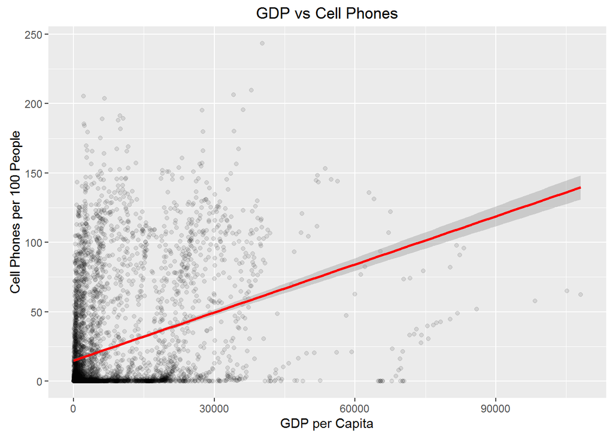

```r
ggplot(aes(x = gdp, y = subs), data = merged) +
  geom_point(alpha = 1/10, position = position_jitter(h = 0)) +
  geom_smooth(method = "lm", color = "red") +
  scale_x_continuous() +
  scale_y_continuous() +
  labs(title = "GDP vs Cell Phones",
       x = "GDP per Capita",
       y = "Cell Phones per 100 People")
```

9j. Look at correlation to reinforce viewpoint

```r
cor.test(merged$gdp, merged$subs, method = "pearson")
```

```
##
##  Pearson's product-moment correlation
##
## data:  merged$gdp and merged$subs
## t = 26.495, df = 5403, p-value < 2.2e-16
## alternative hypothesis: true correlation is not equal to 0
## 95 percent confidence interval:
##  0.3152892 0.3624827
## sample estimates:
##       cor
## 0.3390993
```

9k. Look @ 95th percentiles & correlations to strip out massive outliers. Viewpoint still holds true

9ki. Look @ 95th percentile of GDP - plot & correlation

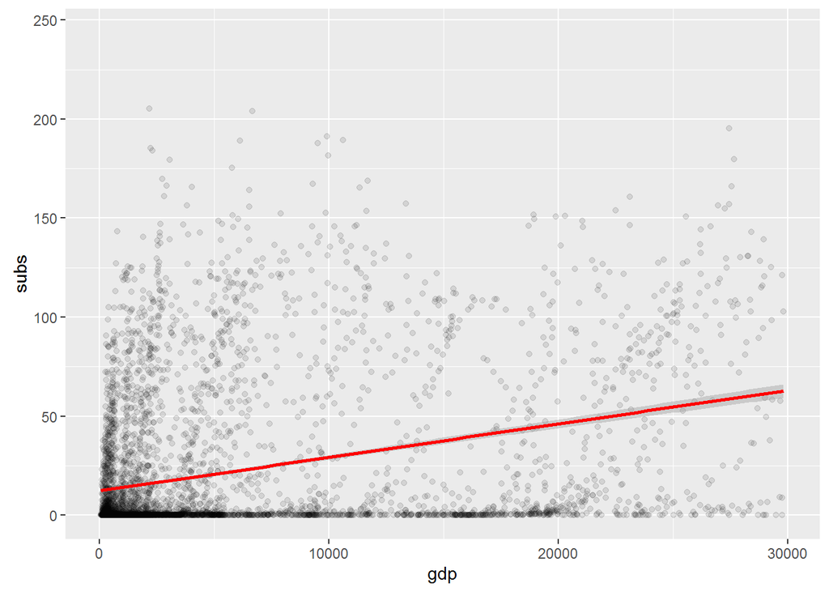

```r
ggplot(aes(x = gdp, y = subs), data = merged) +
  geom_point(alpha = 1/10, position = position_jitter(h = 0)) +
  xlim(0, quantile(merged$gdp, 0.95)) +
  geom_smooth(method = "lm", color = "red")
```

```r
merged_gdp95th <- subset(merged, gdp <= quantile(gdp, 0.95))
cor.test(merged_gdp95th$gdp, merged_gdp95th$subs, method = "pearson")
```

```
##
##  Pearson's product-moment correlation
##
## data:  merged_gdp95th$gdp and merged_gdp95th$subs
## t = 24.645, df = 5132, p-value < 2.2e-16
## alternative hypothesis: true correlation is not equal to 0
## 95 percent confidence interval:
##  0.3006274 0.3495519
## sample estimates:
##       cor
## 0.3253073
```

9kii. Look @ 95th percentile of subs - plot & correlation

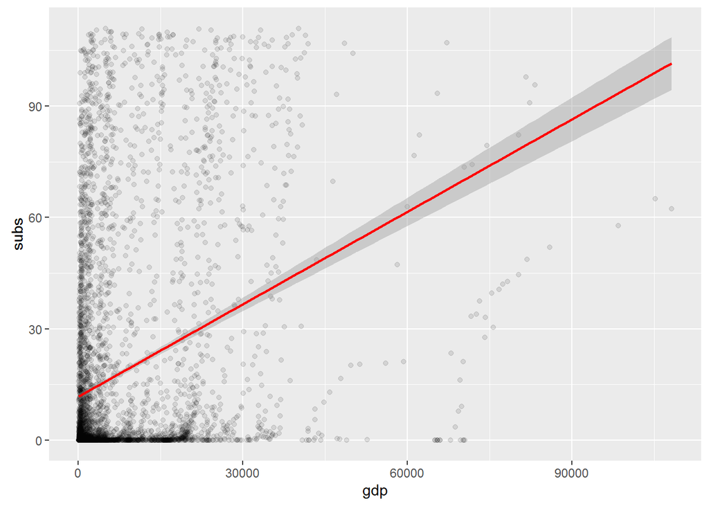

```r
ggplot(aes(x = gdp, y = subs), data = merged) +
  geom_point(alpha = 1/10, position = position_jitter(h = 0)) +
  ylim(0, quantile(merged$subs, 0.95)) +
  geom_smooth(method = "lm", color = "red")
```

```r
merged_subs95th <- subset(merged, subs <= quantile(subs, 0.95))
cor.test(merged_subs95th$gdp, merged_subs95th$subs, method = "pearson")
```

```
##
##  Pearson's product-moment correlation
##
## data:  merged_subs95th$gdp and merged_subs95th$subs
## t = 23.282, df = 5132, p-value < 2.2e-16
## alternative hypothesis: true correlation is not equal to 0
## 95 percent confidence interval:
##  0.2841301 0.3336173
## sample estimates:
##       cor
## 0.3090829
```

9kiii. Look @ 95th percentile for both - plot & correlation

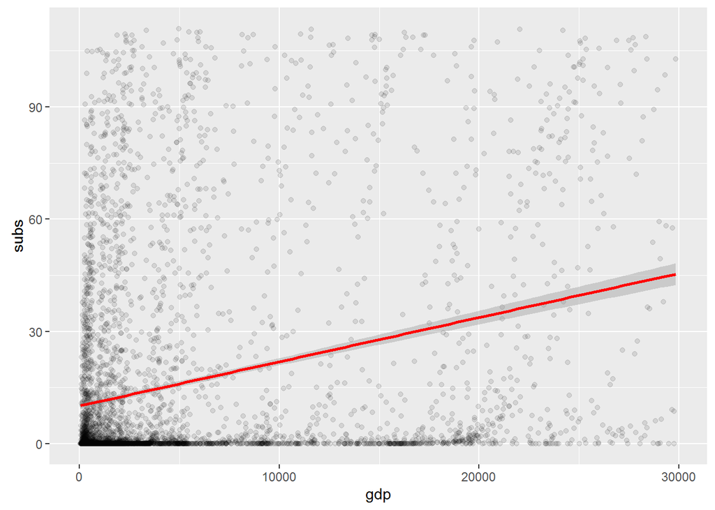

```r
ggplot(aes(x = gdp, y = subs), data = merged) +
  geom_point(alpha = 1/10, position = position_jitter(h = 0)) +
  xlim(0, quantile(merged$gdp, 0.95)) +
  ylim(0, quantile(merged$subs, 0.95)) +
  geom_smooth(method = "lm", color = "red")
```

```r
merged_95th <- subset(merged, gdp <= quantile(gdp, 0.95) & subs <= quantile(subs, 0.95))
cor.test(merged_95th$gdp, merged_95th$subs, method = "pearson")
```

```
##
##  Pearson's product-moment correlation
##
## data:  merged_95th$gdp and merged_95th$subs
## t = 20.898, df = 4907, p-value < 2.2e-16
## alternative hypothesis: true correlation is not equal to 0
## 95 percent confidence interval:
##  0.2599775 0.3113584
## sample estimates:
##       cor
## 0.2858734
```

9l. Add mean, median, percentile (25th, 75th) - ask Srdjan, as this doesn’t work well. Too many data points in y?

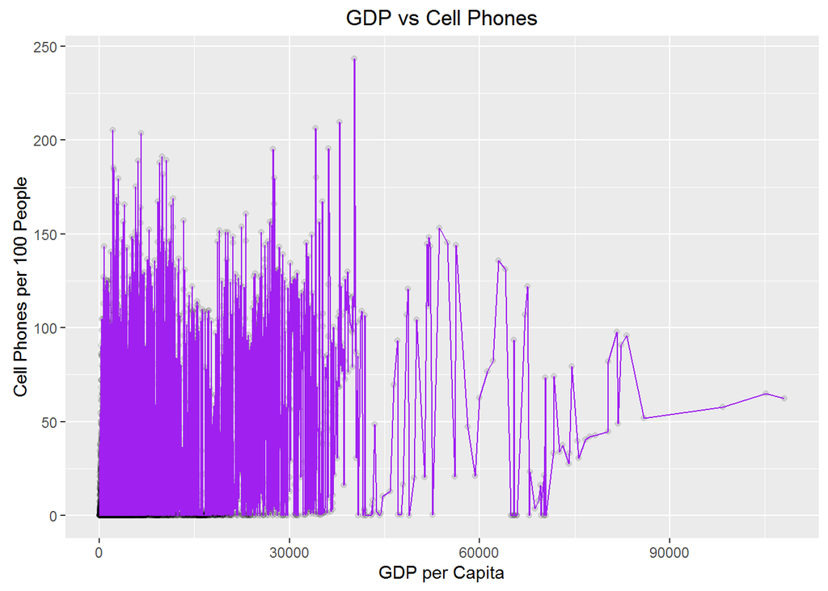

```r
ggplot(aes(x = gdp, y = subs), data = merged) +
  geom_point(alpha = 1/10, position = position_jitter(h = 0)) +
  geom_line(stat = 'summary', fun.y = quantile, fun.args = list(prob = .25), color = 'purple') +
  scale_x_continuous() +
  scale_y_continuous() +
  labs(title = "GDP vs Cell Phones",
       x = "GDP per Capita",
       y = "Cell Phones per 100 People")
```

9m. Focus on a single year - 2011.

```r
merged2011 <- subset(merged, year == 2011)
```

9n. Scatterplot & correlation for 2011 continues to reinforce positive relationship

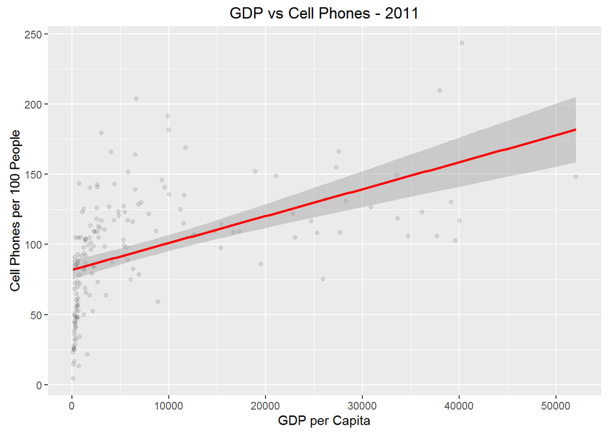

```r
ggplot(aes(x = gdp, y = subs), data = merged2011) +
  geom_point(alpha = 1/10, position = position_jitter(h = 0)) +
  geom_smooth(method = "lm", color = "red") +
  scale_x_continuous() +
  scale_y_continuous() +
  labs(title = "GDP vs Cell Phones - 2011",
       x = "GDP per Capita",
       y = "Cell Phones per 100 People")
```

```r
cor.test(merged2011$gdp, merged2011$subs, method = "pearson")
```

```
##
##  Pearson's product-moment correlation
##
## data:  merged2011$gdp and merged2011$subs
## t = 7.402, df = 163, p-value = 6.77e-12
## alternative hypothesis: true correlation is not equal to 0
## 95 percent confidence interval:
##  0.377732 0.607778
## sample estimates:
##       cor
## 0.5015694
```

9o. Look at top 10 countries & bottom 10 countries for 2011

```r
sorted2011 <- arrange(merged2011, desc(gdp))
top102011 <- head(sorted2011, n = 10)
bottom102011 <- tail(sorted2011, n = 10)
```

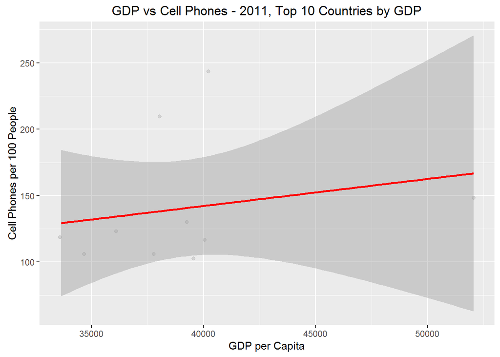

```r
ggplot(aes(x = gdp, y = subs), data = top102011) +
  geom_point(alpha = 1/10, position = position_jitter(h = 0)) +
  geom_smooth(method = "lm", color = "red") +
  scale_x_continuous() +
  scale_y_continuous() +
  labs(title = "GDP vs Cell Phones - 2011, Top 10 Countries by GDP",
       x = "GDP per Capita",
       y = "Cell Phones per 100 People")
```

```r
cor.test(top102011$gdp, top102011$subs, method = "pearson")
```

```
##
##  Pearson's product-moment correlation
##
## data:  top102011$gdp and top102011$subs
## t = 0.62315, df = 8, p-value = 0.5505
## alternative hypothesis: true correlation is not equal to 0
## 95 percent confidence interval:
##  -0.4794161  0.7439947
## sample estimates:
##       cor
## 0.2151556
```

[figure not shown]

```r
ggplot(aes(x = gdp, y = subs), data = bottom102011) +
  geom_point(alpha = 1/10, position = position_jitter(h = 0)) +
  geom_smooth(method = "lm", color = "red") +
  scale_x_continuous() +
  scale_y_continuous() +
  labs(title = "GDP vs Cell Phones - 2011, Top 10 Countries by GDP",
       x = "GDP per Capita",
       y = "Cell Phones per 100 People")
```

```r
cor.test(bottom102011$gdp, bottom102011$subs, method = "pearson")
```

```
##
##  Pearson's product-moment correlation
##
## data:  bottom102011$gdp and bottom102011$subs
## t = 2.5174, df = 8, p-value = 0.03595
## alternative hypothesis: true correlation is not equal to 0
## 95 percent confidence interval:
##  0.06058336 0.91249787
## sample estimates:
##       cor
## 0.6648491
```